# CALIDAD DEL AGUA DEL RIO RIMAC

**GRAFICO 1**

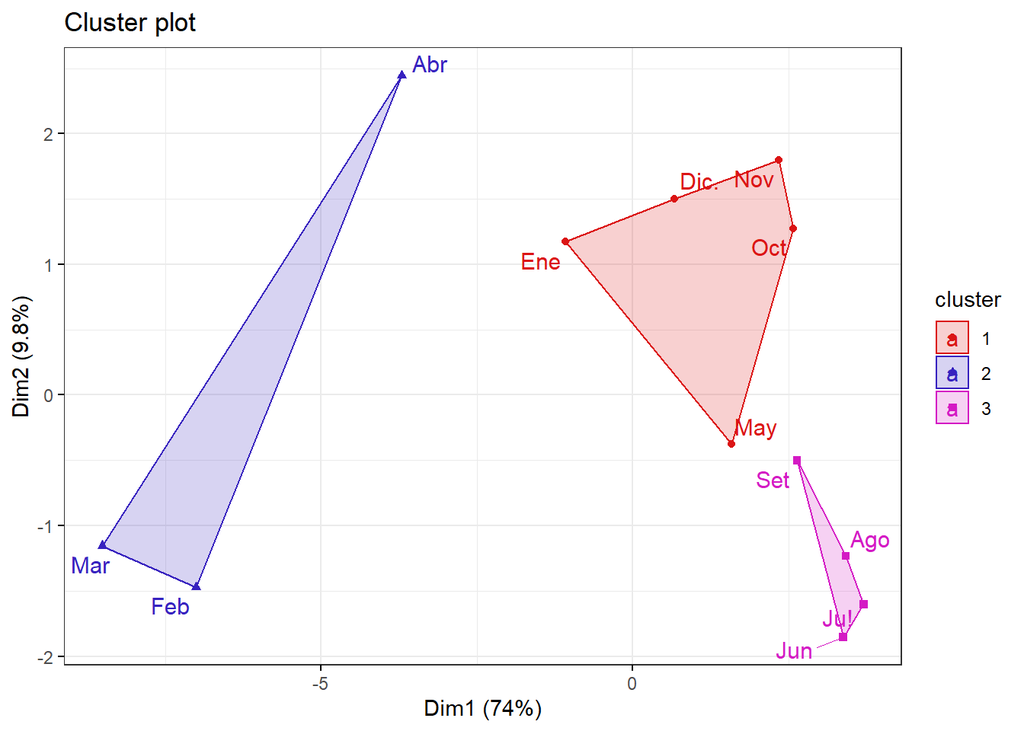

```r
#Se puede apreciar que con 2 componentes retenemos 83.8% de la inercia total
library(factoextra)
fviz_cluster(list(data = datosc, cluster = grp),
             palette =c("#DB1515", "#3722BF", "#D41AC4") ,
             ellipse.type = "convex", # Concentration ellipse
             repel = T, # Avoid label overplotting (slow)
             show.clust.cent = FALSE, ggtheme = theme_bw())
```

**Insumo para un modelo predictivo como regresion lineal**

```r
# Juntando el archivo de "datos" con la columna de "cluster"
datos.j <- cbind(datosc,grp)
```

```r
#convirtiendo en factor la varaible "grp"
datos.j$grp <- factor(datos.j$grp)

#Si deseamos exportar :
# write.csv(datos.j,"Compras con Jerarquico Aglomerativo.csv")
```

**Analisis de componenentes principales:**

En las variables(24)

ANALISIS EXPLORATORIO :

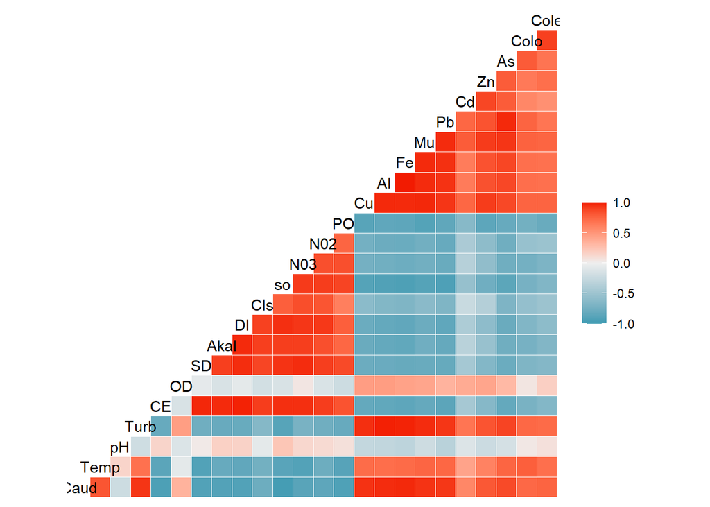

```r
library(GGally)
ggcorr(datosc)
```

```r
#Se puede observar  que entre las 24 variables,
#hay correlaciones muy altas , correlaciones altas  y correlaciones medias.
#esto podria traer problemas de multicolinealidad.
```

**3.2Análisis de Componentes Principales con el paquete ade4**

CORROBORANDO LA **GRAFICA 1**

¿se podra explicar con 2 componentes todas las 24 variables ?

vamos a comprobar:

En el **Grafico 1**, se podia apreciar que  
con 2 componentes(retiene 83.8% de la inercia total) se podria explicar todas las 24 variables.

**¿Cuantos componentes?**

```r
library(ade4)

acp <- dudi.pca(datosc,scannf=FALSE,nf=ncol(datosc))
summary(acp)
```

```
## Class: pca dudi
## Call: dudi.pca(df = datosc, scannf = FALSE, nf = ncol(datosc))
##
## Total inertia: 24
##
## Eigenvalues:
##     Ax1     Ax2     Ax3     Ax4     Ax5
## 17.7541  2.3548  1.3683  0.9189  0.5800
##
## Projected inertia (%):
##     Ax1     Ax2     Ax3     Ax4     Ax5
##  73.976   9.812   5.701   3.829   2.417
##
## Cumulative projected inertia (%):
##     Ax1   Ax1:2   Ax1:3   Ax1:4   Ax1:5
##   73.98   83.79   89.49   93.32   95.73
##
## (Only 5 dimensions (out of 11) are shown)
```

**- Podemos observar que con 2 componenetes retenemos 83.79 % de la inercia total**

- Podemos observar que con 3 componenetes retenemos 89.49 % de la inercia total
- Podemos observar que con 4 componenetes retenemos 93.32 % de la inercia total
- Podemos observar que con 5 componenetes retenemos 95.73 % de la inercia total

**CRITERIO DE LA MEDIA**

```r
# Valores propios

#el criterio de la media:
acp$eig
```

```
##  [1] 17.75412281  2.35476144  1.36828719  0.91885927  0.58004727  0.40691705
##  [7]  0.24251967  0.16344726  0.11008407  0.06970343  0.03125052
```

```r
#estamos trabajando con la matriz correlacion cada variable deberia retener
#1% de la inercia total , nos podemos quedar hasta  con 3 componenetes(89.49% inercia total)
#pero tambien con 2 componentes se retiene  83.79% (inercia total)
```

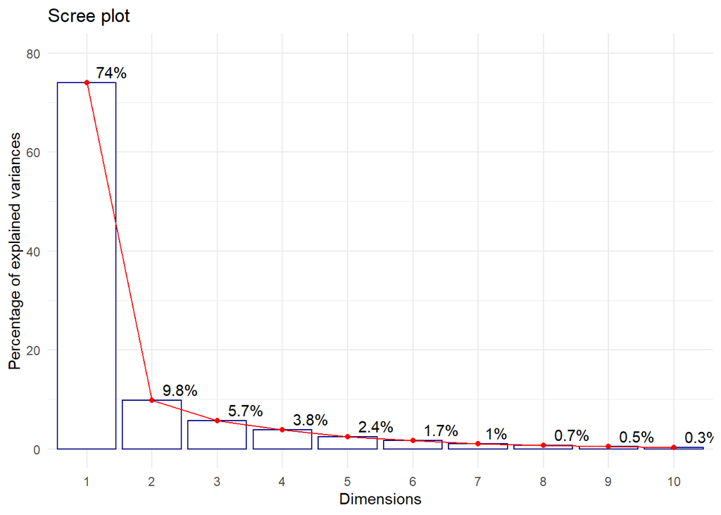

```r
# Grafica de Valores propios - ScreePlot

#El primer componente retiene 74% de la inercia total
#El segundo componete retiene 9.8% de la inercia total
#El tercer componente retiene 5.7% de la inercia total
fviz_eig(acp, addlabels=TRUE, hjust = -0.3,
         barfill="white", barcolor ="darkblue",
         linecolor ="red") + ylim(0,80) + theme_minimal()
```

**Conclusion:**

Con 2 componentes podemos explicar todas las 24 variables reteniendo 83.79% % de la inercia total

```r
#Por eso que en  la GRAFICA 1 , la agrupacion de los meses  en 3  cluster
#se explica   83.79% (inercia total).
inertia.dudi(acp)
```

```
## Inertia information:
## Call: inertia.dudi(x = acp)
##
## Decomposition of total inertia:
##       inertia     cum  cum(%)
## Ax1  17.75412   17.75   73.98
## Ax2   2.35476   20.11   83.79
## Ax3   1.36829   21.48   89.49
## Ax4   0.91886   22.40   93.32
## Ax5   0.58005   22.98   95.73
## Ax6   0.40692   23.38   97.43
## Ax7   0.24252   23.63   98.44
## Ax8   0.16345   23.79   99.12
## Ax9   0.11008   23.90   99.58
## Ax10  0.06970   23.97   99.87
## Ax11  0.03125   24.00  100.00
```

**ANALISIS DE COMPONENTES PRINCIPALES**

Con 2 componentes principales

```r
acp <- dudi.pca(datosc,scannf=FALSE,nf=2)
summary(acp)
```

```
## Class: pca dudi
## Call: dudi.pca(df = datosc, scannf = FALSE, nf = 2)
##
## Total inertia: 24
##
## Eigenvalues:
##     Ax1     Ax2     Ax3     Ax4     Ax5
## 17.7541  2.3548  1.3683  0.9189  0.5800
##
## Projected inertia (%):
##     Ax1     Ax2     Ax3     Ax4     Ax5
##  73.976   9.812   5.701   3.829   2.417
##
## Cumulative projected inertia (%):
##     Ax1   Ax1:2   Ax1:3   Ax1:4   Ax1:5
##   73.98   83.79   89.49   93.32   95.73
##
## (Only 5 dimensions (out of 11) are shown)
```

¿Como estan agrupadas las variables?

Nos basamos del criterio de las correlaciones

```r
# Correlaciones entre las variables y los componentes


#acp$c1 vectores propios
acp$co[c(1,2)]
```

|  | Comp1 | Comp2 |
| --- | --- | --- |
| Caud | -0.9856905 | -0.01901796 |
| Temp | -0.8575730 | 0.34464942 |
| pH | 0.1718367 | 0.32044552 |
| Turb | -0.9346113 | -0.23625366 |
| CE | 0.9441237 | -0.27906809 |
| OD | -0.2805474 | -0.66047211 |
| SD | 0.9217281 | -0.33148387 |
| Akal | 0.9013802 | -0.30784486 |
| DI | 0.9190383 | -0.32601318 |
| Cls | 0.7834060 | -0.44555826 |

[output cut: 14 more lines]

**componente1:#FACTORES DE NO AIREACION**

caudal temp Turb CE SD Akal Di Cls so NO3 NO2 PO Cu Al Fe Mu Pb Cd Zn As Colo Cole

**componente2:# FACTORES DE AIREACION**

OD pH

https://www.hannacolombia.com/aqua/blog/item/midiendo-ph-y-od-en-tanques-de-aireacion-de-aguas-residuales#:~:text=Adem%C#3%A1s%20de%20una%20variedad%20de,microbianas%2C%20y%20permitirles%20una%20actividad

**GRAFICA 2**

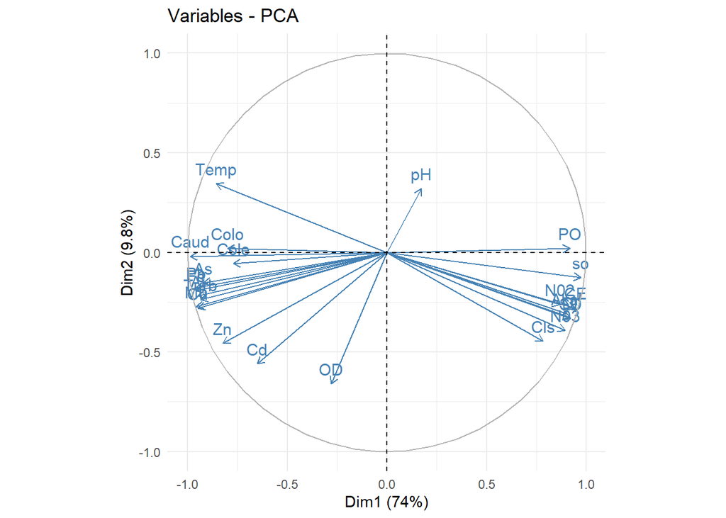

```r
library(factoextra)
fviz_pca_var(acp, col.var="steelblue")+theme_minimal()
```

```r
#podemos observar que todos las variables  estan asociados mas a la  dimension1(componente1),
#excepto las variables "pH" y "OD" que pertenecen a  la dimension2(componente2) pero
#con la matriz de correlacion ya determinamos la variable "pH" y "OD" pertenece a la dimension2.
```

**VARIABLES DE NO AIRIACION**, a medida que aumentan las variables(caudal,temperatura(temp),turbidez(Turb), cobre(Cu),aluminio(Al),Hierro(Fe),Manganeso(Mn),Plomo(Pb),cadmio(Cd),Zinc(Zn),Arsenico(As), Coliformes totales(CoTo),Coliformes termotolerables(Cote) de forma inversamente proporcional disminuye las variables(Coductividad electrica(CE),Solidos Disuelto(SD),Alcalinidad(Akal),Dureza total(DI),cloruros(cls) ,sulfatos(so),nitratos(NO3),nitritos(NO2),fosfatos(PO))

**Por ejemplo con la variable “Alcalinidad(Akal)”**

Una alta alcalinidad(Akal)

**por ejemplo** a una alta alcalinidad(Akal) tambien afectara de manera directa a las variables (Coductividad electrica(CE),Solidos Disuelto(SD) ,Dureza total(DI),cloruros(cls),sulfatos(so),nitratos(NO3),nitritos(NO2),fosfatos(PO)) y tambien afectara de manera inversamente inversamente proporcional a las variables (caudal,temperatura(temp),turbidez(Turb),cobre(Cu),aluminio(Al),Hierro(Fe),Manganeso(Mn), Plomo(Pb),cadmio(Cd),Zinc(Zn),Arsenico(As),Coliformes totales(CoTo),Coliformes termotolerables(Cote) .

¿Si aumenta la cantidad de plomo(Pb) en el rio rimac ,afectara sobre en la Alcalinidad(AKal) ?

Si aumenta la concentracion de plomo(Pb) afectara a la Alcalinidad(Akal) de manera negativa es decir disminuye la concentracion de alcalinidad.

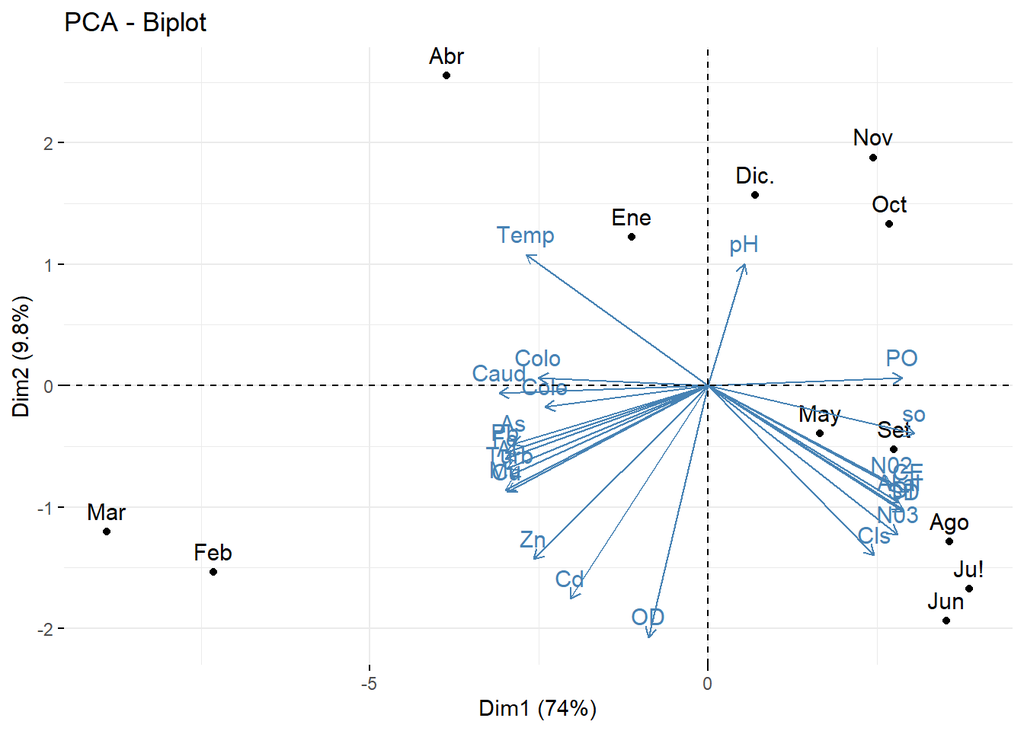

```r
#biplot

library(factoextra)
fviz_pca_biplot(acp, repel = F,
                col.var = "steelblue",
                col.ind = "black" )
```

Los meses febrero,marzo ,abril que corresponde a la estacion de “avenida” esta asociada a la caudal temperatura,turb,Cu,Fe,Mn,Pb,As,cote y coto. Los meses octubre,noviembre,diciembre , enero y mayo que corresponde a la estacion de “transicion” esta asociada Ph,Po,so de forma inversamente proporcional Zn,Cd y OD. Los meses junio, julio ,agosto ,setiembreque corresponde a la estacion de “estiage” esta asociado Ce,Sd,Akal,Di,Cls,NO3 Y NO2.

**SCORES**

**Insumo para modelos predictivos como regresion lineal**

```r
# Scores o Puntuaciones de cada individuo

#10 primeros
acp$li[1:10,]
```

|  | Axis1 | Axis2 |
| --- | --- | --- |
| Ene | -1.127415 | 1.2241429 |
| Feb | -7.321424 | -1.5374149 |
| Mar | -8.892270 | -1.2061457 |
| Abr | -3.864966 | 2.5559978 |
| May | 1.653208 | -0.3952227 |
| Jun | 3.526615 | -1.9367091 |
| Ju! | 3.869064 | -1.6735475 |
| Ago | 3.572872 | -1.2874593 |
| Set | 2.750543 | -0.5237799 |
| Oct | 2.683794 | 1.3317449 |

Practicamente no estan correlacionados los 2 componentes (-0.00000000000000005023342)

```r
cor(acp$li)
```

```
##                            Axis1                      Axis2
## Axis1  1.00000000000000000000000 -0.00000000000000005023342
## Axis2 -0.00000000000000005023342  1.00000000000000000000000
```